# 딥러닝

`YOLO`: 객체 탐지

[Tidyverse Korea](https://www.facebook.com/groups/tidyverse/)

Tidyverse Korea

2020-06-30

# 1 `YOLO`[^1][^2][^3][^4]

객체 분류(object classification)을 위해서 먼저 해야 될 작업이 아마도 객체를 탐지하는 것이 아닐까 싶다. MNIST와 같은 데이터는 이미 손글씨를 탐지해서 인식 및 분류를 위한 사전준비가 완료된 상황이고, 대부분의 객체분류문제는 먼저 객체를 탐지하는 것부터 시작된다.

신경망 분류모형은 기본적으로 지도학습(Supervised Learning)이라 라벨 작업이 먼저 사람에 의해 이뤄져야 한다. 이미지 라벨작업을 수월히 하는데 [`LabelImg`](https://github.com/tzutalin/labelImg) 등 도구가 있어 `YOLO` 모형 개발에 필요한 라벨 생성작업에 도움을 줄 듯 싶다.

- [`LabelImg`](https://github.com/tzutalin/labelImg)

## 1.1 탐지 대상 이미지

이미지에서 객체가 위치한 곳을 제대로 탐지하는지 먼저 살펴보자. 이를 위해서 대상 이미지를 `magick` 팩키지로 살펴보자.

```r
library(tidyverse)
library(magick)

airplane <- image_read("fig/airplane.jpeg")

airplane %>%
  image_resize(200)
```

[output not shown]

## 1.2 `YOLO` 팩키지 설치

`image.darkent` 팩키지를 설치하여 이미지에서 `YOLO` 알고리즘으로 이미지 탐지를 위한 팩키지를 설치한다.

```r
devtools::install_github("bnosac/image",
                         subdir = "image.darknet",
                         build_vignettes = TRUE)
```

## 1.3 `YOLO` 실행

[`YOLO` Real-Time Object Detection](https://pjreddie.com/darknet/yolo/)이 현재 가장 성능이 좋다고 하며, 파스칼 타이탄 X (Pascal Titan X) GPU 칩을 기준으로 초당 30 프레임(30 FPS) 속도로 [`COCO` 데이터셋](https://cocodataset.org/#home) 기준 mAP(mean Average Precision) 57.9%을 기록하고 있다.

```r
library(image.darknet)

labels_COCO <- readLines(
  system.file(package="image.darknet", "include", "darknet", "data",
              "coco.names")
)

yolo_cfg <- "DL_library//yolov2.cfg"
yolo_weights <- "DL_library/yolov2.weights"

yolo_COCO <- image_darknet_model(type = 'detect',
                                 model = yolo_cfg,
                                 weights = yolo_weights,
                                 labels = labels_COCO)

# yolo_COCO$labels

image_darknet_detect(file = "fig/airplane.jpeg",
                     object = yolo_COCO,
                     threshold = 0.5)
```

[output not shown]

## 1.4 데이터프레임 변환

`predictions.png` 파일로 출력결과만 떨어질 뿐, 후속 작업을 위한 텍스트를 잡아낼 수 없기 때문에 `yolo` 알고리즘 실행 중 콘솔에 떨어지는 출력결과를 방향을 바꿔(redirect)시켜 파일에 텍스트로 떨어뜨린다.

```r
## lapply 적용을 위한 함수: 매개변수 다수 전달
detect_object <- function(filename){

  pred <- image_darknet_detect(file = filename,
                               object = yolo_COCO,
                               threshold = 0.19)
  }

# detect_object("fig/airplane.jpeg")

## 결과값을 가로채는 함수

library(Rcpp)
cppFunction('void redir() {FILE* F = freopen("capture.txt", "w+", stdout);}')
redir()

yolo_df <- lapply("fig/airplane.jpeg", detect_object)

yolo_df <- tibble(text = read_lines("capture.txt"))

system("rm capture.txt")

yolo_df
```

```
# A tibble: 0 x 1
# … with 1 variable: text <chr>
```

# 2 다수 이미지

먼저 다수 이미지를 가져온다. 이를 `yolo` 알고리즘을 태우고 텍스트 파일에 저장한다.

```r
## 대상 이미지 지정
filenames <- list.files(path = "fig/yolo/")
path_filenames <- glue::glue("fig/yolo/{filenames}")

## 다수 이미지 위치 정보를 텍스트로 저장
redir()
image_df <- lapply(path_filenames, detect_object)
image_df <- tibble(text = read_lines("capture.txt"))

system("rm capture.txt")

# image_df %>% write_rds("data/image_df.rds")
```

텍스트로 추출한 데이터를 후속 처리가 가능한 데이터프레임으로 변환시킨다.

```r
image_dat <- read_rds("data/image_df.rds")

image_df <- image_dat %>%
  filter(!str_detect(text, "^Boxes")) %>%
  mutate(file = str_extract(text, ".*\\.jpe?g")) %>%
  tidyr::fill(file, .direction = "down") %>%
  mutate(file = str_remove(file, "fig/yolo/"))

image_df <- image_df %>%
  mutate(processing = str_extract(text, "\\d\\.\\d+ seconds")) %>%
  tidyr::fill(processing) %>%
  separate(text, into = c("object", "confidence"), sep=":") %>%
  filter(!str_detect(object, "fig/yolo/")) %>%
  mutate(confidence = str_trim(confidence)) %>%
  select(file, processing, object, confidence)

image_df
```

```
# A tibble: 12 x 4
   file                     processing       object    confidence
   <chr>                    <chr>            <chr>     <chr>
 1 airplane_and_ship.jpg    8.485884 seconds aeroplane 77%
 2 airplane_and_ship.jpg    8.485884 seconds boat      60%
 3 airplane_lighthouse.jpeg 8.717672 seconds aeroplane 85%
 4 airplane_ship_ocean.jpeg 8.447571 seconds aeroplane 86%
 5 airplane_ship_ocean.jpeg 8.447571 seconds boat      42%
 6 airplane_ship_ocean.jpeg 8.447571 seconds boat      79%
 7 cat_dog.jpg              8.347606 seconds dog       25%
 8 cat_dog.jpg              8.347606 seconds orange    29%
 9 cat_dog.jpg              8.347606 seconds cat       68%
10 cats_dogs.jpeg           8.373252 seconds dog       64%
11 cats_dogs.jpeg           8.373252 seconds person    19%
12 cats_dogs.jpeg           8.373252 seconds cat       95%
```

## 2.1 다수 이미지 시각화

다수 이미지를 `YOLO` 알고리즘으로 추출하여 작업한 결과를 이미지와 텍스트로 저장시켜 두고 이를 제대로 작업했는지 시각적으로 확인하는 과정을 거친다.

```r
## lapply 적용을 위한 함수: 매개변수 다수 전달
detect_object <- function(filename){

  pred <- image_darknet_detect(file = filename,
                               object = yolo_COCO,
                               threshold = 0.19)

  file_extension <- basename(filename)
  only_filename <- tools::file_path_sans_ext(file_extension)

  mv_instruction <- glue::glue("mv predictions.png fig/yolo/{only_filename}_yolo.png")
  # system("mv predictions.png fig/yolo/predictions.png")
  system(mv_instruction)
  }

# detect_object("fig/airplane.jpeg")

## 결과값을 가로채는 함수
library(Rcpp)
cppFunction('void redir() {FILE* F = freopen("capture.txt", "w+", stdout);}')
redir()

## 배치처리
redir()
image_df <- lapply(path_filenames, detect_object)
image_df <- tibble(text = read_lines("capture.txt"))

system("rm capture.txt")
```

이제 작업된 결과를 다음과 같은 방식으로 후속작업을 할 수 있다.

1. 쌓은 이미지: `magick` 팩키지 `stack` 기능
2. GIF 이미지: `magick` 팩키지 `GIF` 기능
3. 회전목마 이미지(carousel): `slickR`
4. R마크다운 `.tabset` 기능
5. `trelliscopeJS` 기능

`magic` 팩키지를 통해 다양한 작업을 배치처리 하고자 할 경우 먼저 이미지를 리스트로 만들고 이를 `image_join()` 함수를 사용해서 결합을 시키고 나서, GIF 로 만들어 최종 결과물을 만들어 낸다.

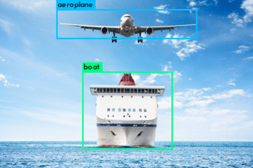

```r
## 이미지 파일 목록
yolo_path_filenames <- glue::glue("fig/yolo/{list.files('fig/yolo')}")

## 이미지 파일 객체
yolo_images <- map(yolo_path_filenames, magick::image_read)
yolo_images <- map(yolo_images, magick::image_resize, geometry = 500 )

## 이미지 파일 결합: list --> 데이터프레임
yolo_images_data <- yolo_images %>%
  image_join()

## GIF 생성: 데이터프레임 --> GIF
yolo_images_data %>%
  image_animate(fps = 1)
```